# Machine Learning Project: Weight Lifting Exercise

### **II.Pre-Processing Data and Exploratory Analysis**

#### Packages required

```r
options(warn = -1)
library(ggplot2)
library(caret)
library(randomForest)
library(parallel)
library(gbm)
library(plyr)
library(rpart)
```

#### Loading Data

The training and testing datasets are downloaded from this [source](http://groupware.les.inf.puc-rio.br/har). Blank observations were converted into “NA” when reading the csv files.

```r
train.raw <-read.csv("./trainraw.csv", na.strings=c("NA","", " "))
test.raw <-read.csv("./testraw.csv", na.strings=c("NA","", " "))
```

#### Cleaning Data

Number of columns with at least one “NA” are checked. Both the training and testing datasets have 100 variables with at least 1 “NA”.

```r
#check number of variables with NAs in training set
is_col_na <- (colSums(is.na(train.raw)) > 0)
str(train.raw[, is_col_na], list.len=0)
```

```
## 'data.frame':    19622 obs. of  100 variables:
##   [list output truncated]
```

```r
#check number of variables with NAs in testing set
is_col_na <- (colSums(is.na(test.raw)) > 0)
str(test.raw[, is_col_na], list.len=0)
```

```
## 'data.frame':    20 obs. of  100 variables:
##   [list output truncated]
```

New dataframes- ‘training’ and ‘testing’ are created removing these 100 variables which leaves each set with 60 variables.

```r
training<-train.raw[, colSums(is.na(train.raw))==0]
testing<-test.raw[, colSums(is.na(test.raw))==0]
```

The first seven variables in both sets are identifiers and timestamps which are not useful predictors. These seven unnecessary variables are removed from both sets. The tidy dataset consists of 52 predictors and 1 outcome variable in the training set and 52 predictors and 1 identification variable in the testing set.

```r
training<-training[,-(1:7)]
testing<-testing[,-(1:7)]
dim(training); dim(testing)
```

```
## [1] 19622    53
```

```
## [1] 20 53
```

#### Exploratory Analysis

The following histogram shows that class A which represents the correct weight lifting technique has the highest frequency, while classes B, C, D and E representing the incorrect excercise technique have counts below 4000.

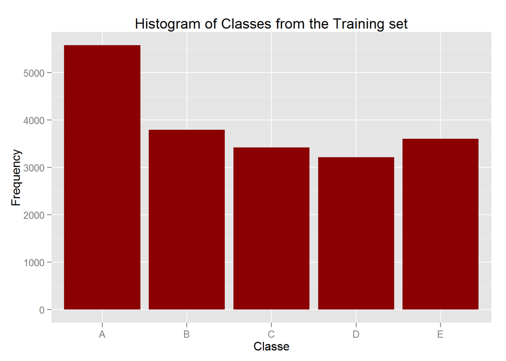

```r
g<-ggplot(training,aes(x=classe))+
  geom_histogram(binwidth=.5, fill = "dark red")+
  labs(x="Classe",y="Frequency")+ scale_y_continuous(breaks=seq(0, 6000, 1000))+
  ggtitle("Histogram of Classes from the Training set")
g
```

```r
table(training$classe)
```

```
##
##    A    B    C    D    E
## 5580 3797 3422 3216 3607
```

### **III.Model Building and Cross Validation**

First, the training dataset is split into a training set and a cross-validation set using a 70:30 split.

```r
inTrain<-createDataPartition(y=training$classe,p=0.7, list = FALSE)
trainset<-training[inTrain,]
crossvalset<-training[-inTrain,]
dim(trainset); dim(crossvalset)
```

```
## [1] 13737    53
```

```
## [1] 5885   53
```

Given that the outcome variable “classe” is a categorical variable taking five values, we use Random Forest, Classification and Regression Tree(CART) and Gradient Boosting Machine(GBM) to build our training model. Random Forest is both easier to tune and is supposed to correct for overfitting. The model with the highest accuracy or lowest out of sample error will be used for predicting “classe” on the testing dataset.

#### Training with Random Forest Model

To optimize computation speed, ‘parallel’ and ‘trControl’ parameters are used where the model is trained with cross validation of 4 resampling iterations with the Random Forest Model.

```r
set.seed(1234)
mod.rf <- randomForest(classe~.,method="class", data=trainset, trControl= trainControl(method = "cv",number = 4,allowParallel = TRUE))
```

#### Cross Validation with Random Forest Model

Cross validation is applied on the cross-val data set and a confusion matrix is build to assess the accuracy and out-of-sample error of this model.

```r
set.seed(1234)
cv.rf<-predict(mod.rf, crossvalset)
c1<-confusionMatrix(crossvalset$classe, cv.rf)
c1
```

```
## Confusion Matrix and Statistics
##
##           Reference
## Prediction    A    B    C    D    E
##          A 1674    0    0    0    0
##          B    7 1128    4    0    0
##          C    0    4 1021    1    0
##          D    0    0   14  948    2
##          E    0    0    3    1 1078
##
## Overall Statistics
##
##                Accuracy : 0.9939
##                  95% CI : (0.9915, 0.9957)
##     No Information Rate : 0.2856
##     P-Value [Acc > NIR] : < 2.2e-16
##
##                   Kappa : 0.9923
##  Mcnemar's Test P-Value : NA
##
## Statistics by Class:
##
##                      Class: A Class: B Class: C Class: D Class: E
## Sensitivity            0.9958   0.9965   0.9798   0.9979   0.9981
## Specificity            1.0000   0.9977   0.9990   0.9968   0.9992
## Pos Pred Value         1.0000   0.9903   0.9951   0.9834   0.9963
## Neg Pred Value         0.9983   0.9992   0.9957   0.9996   0.9996
## Prevalence             0.2856   0.1924   0.1771   0.1614   0.1835
## Detection Rate         0.2845   0.1917   0.1735   0.1611   0.1832
## Detection Prevalence   0.2845   0.1935   0.1743   0.1638   0.1839
## Balanced Accuracy      0.9979   0.9971   0.9894   0.9973   0.9987
```

#### Training with Classification and Regression Tree(CART)

CART is used to train the model with cross validation of 4 resampling iterations.

```r
set.seed(1234)
mod.cart <-train(classe~., method="rpart", data=training, trControl= trainControl(method = "cv",number = 4,allowParallel = TRUE))
```

#### Cross Validation with Classification and Regression Tree(CART)

```r
set.seed(1234)
cv.cart<-predict(mod.cart, crossvalset)

c2<-confusionMatrix(crossvalset$classe, cv.cart)
c2
```

```
## Confusion Matrix and Statistics
##
##           Reference
## Prediction    A    B    C    D    E
##          A 1531   34  104    0    5
##          B  462  407  270    0    0
##          C  465   36  525    0    0
##          D  408  176  380    0    0
##          E  141  136  300    0  505
##
## Overall Statistics
##
##                Accuracy : 0.5043
##                  95% CI : (0.4915, 0.5172)
##     No Information Rate : 0.511
##     P-Value [Acc > NIR] : 0.8485
##
##                   Kappa : 0.3529
##  Mcnemar's Test P-Value : NA
##
## Statistics by Class:
##
##                      Class: A Class: B Class: C Class: D Class: E
## Sensitivity            0.5091  0.51584  0.33249       NA  0.99020
## Specificity            0.9503  0.85636  0.88365   0.8362  0.89265
## Pos Pred Value         0.9146  0.35733  0.51170       NA  0.46673
## Neg Pred Value         0.6495  0.91951  0.78308       NA  0.99896
## Prevalence             0.5110  0.13407  0.26831   0.0000  0.08666
## Detection Rate         0.2602  0.06916  0.08921   0.0000  0.08581
## Detection Prevalence   0.2845  0.19354  0.17434   0.1638  0.18386
## Balanced Accuracy      0.7297  0.68610  0.60807       NA  0.94142
```

#### Training with Gradient Boosting Machine(GBM)

GBM is used to train the model with cross validation of 4 resampling iterations.

```r
set.seed(1234)
mod.gbm <- train(classe~., method="gbm",data=trainset,trControl= trainControl(method = "cv",number = 4, verboseIter = FALSE), verbose= FALSE)
```

#### Cross Validation with Gradient Boosting Machine(GBM)

```r
set.seed(1234)
cv.gbm<-predict(mod.gbm, crossvalset)
c2<-confusionMatrix(crossvalset$classe, cv.gbm)
c2
```

```
## Confusion Matrix and Statistics
##
##           Reference
## Prediction    A    B    C    D    E
##          A 1643   27    4    0    0
##          B   31 1077   30    1    0
##          C    0   34  983    8    1
##          D    0    1   34  915   14
##          E    2    7    7   14 1052
##
## Overall Statistics
##
##                Accuracy : 0.9635
##                  95% CI : (0.9584, 0.9681)
##     No Information Rate : 0.2848
##     P-Value [Acc > NIR] : < 2.2e-16
##
##                   Kappa : 0.9538
##  Mcnemar's Test P-Value : NA
##
## Statistics by Class:
##
##                      Class: A Class: B Class: C Class: D Class: E
## Sensitivity            0.9803   0.9398   0.9291   0.9755   0.9859
## Specificity            0.9926   0.9869   0.9911   0.9901   0.9938
## Pos Pred Value         0.9815   0.9456   0.9581   0.9492   0.9723
## Neg Pred Value         0.9922   0.9855   0.9846   0.9953   0.9969
## Prevalence             0.2848   0.1947   0.1798   0.1594   0.1813
## Detection Rate         0.2792   0.1830   0.1670   0.1555   0.1788
## Detection Prevalence   0.2845   0.1935   0.1743   0.1638   0.1839
## Balanced Accuracy      0.9865   0.9634   0.9601   0.9828   0.9899
```

#### Accuracy and Out-of-Sample Error

```r
missClass = function(values,prediction){sum(prediction!= values)/length(values)}

#Misclassification Rate from Random Forest Model
missClass(crossvalset$classe, predict(mod.rf,crossvalset))
```

```
## [1] 0.006117247
```

```r
#Misclassification Rate from CART Model
missClass(crossvalset$classe, predict(mod.cart,crossvalset))
```

```
## [1] 0.4956669
```

```r
#Misclassification Rate from GBM Model
missClass(crossvalset$classe, predict(mod.gbm,crossvalset))
```

```
## [1] 0.03653356
```

### **IV.Prediction**

The Random Forest prediction algorithm which was previously created is applied on the test set of 20 observations. The table shows the distribution of 20 test cases among the five classes.

```r
pre.rf<-predict(mod.rf, testing)
pre.rf
```

```
##  1  2  3  4  5  6  7  8  9 10 11 12 13 14 15 16 17 18 19 20
##  B  A  B  A  A  E  D  B  A  A  B  C  B  A  E  E  A  B  B  B
## Levels: A B C D E
```

```r
table(pre.rf)
```

```
## pre.rf
## A B C D E
## 7 8 1 1 3
```

### **References**

Ugulino, W.; Cardador, D.; Vega, K.; Velloso, E.; Milidiu, R.; Fuks, H. Wearable Computing: Accelerometers’ Data Classification of Body Postures and Movements. Proceedings of 21st Brazilian Symposium on Artificial Intelligence. Advances in Artificial Intelligence - SBIA 2012. In: Lecture Notes in Computer Science. , pp. 52-61. Curitiba, PR: Springer Berlin / Heidelberg, 2012. ISBN 978-3-642-34458-9. DOI: 10.1007/978-3-642-34459-6_6.